# Gym Analysis Projecg

Lex Chaffee

2025-01-17

Let’s start off with my initial guess that the Frequency of gym attendance is determined by variables such as age, gender, weight, height, and bpm

```r
#multiple linear regression of different variables
model <- lm(Freq ~ Age + Gender + Weight + Height + AvgBPM, data = gym_data)
summary(model)
```

```
##
## Call:
## lm(formula = Freq ~ Age + Gender + Weight + Height + AvgBPM,
##     data = gym_data)
##
## Residuals:
##     Min      1Q  Median      3Q     Max
## -1.3679 -0.3459 -0.3024  0.6807  1.7254
##
## Coefficients:
##               Estimate Std. Error t value Pr(>|t|)
## (Intercept)  3.415e+00  5.755e-01   5.934 4.11e-09 ***
## Age          6.697e-04  2.420e-03   0.277    0.782
## GenderMale  -3.421e-02  8.294e-02  -0.412    0.680
## Weight      -1.984e-05  1.703e-03  -0.012    0.991
## Height      -6.317e-04  2.837e-01  -0.002    0.998
## AvgBPM      -6.886e-04  2.048e-03  -0.336    0.737
## ---
## Signif. codes:  0 '***' 0.001 '**' 0.01 '*' 0.05 '.' 0.1 ' ' 1
##
## Residual standard error: 0.9152 on 967 degrees of freedom
## Multiple R-squared:  0.0005478,  Adjusted R-squared:  -0.00462
## F-statistic: 0.106 on 5 and 967 DF,  p-value: 0.991
```

So now let’s create a correlation matrix to see which variables are correlated to try and make a better model.

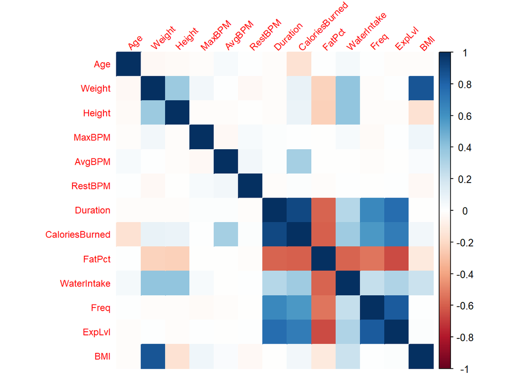

```r
#correlation matrix of all numerical variables
gym_numeric <- gym_data %>% select(where(is.numeric))
cor_matrix <- cor(gym_numeric)
corrplot(cor_matrix, method = "color", tl.srt = 45, tl.cex = .75)
```

Let’s say we want to see if some predictor variables have an impact on the frequency of attendance on gym goers. So let’s compute a multiple linear regression model for Frequency with Duration, Fat Percentage, and Experience Level as the predictor variables due to their relatively high correlation with Frequency

```r
#multiple linear regression of different variables
model <- lm(Freq ~ Duration + FatPct + ExpLvl, data = gym_data)
summary(model)
```

```
##
## Call:
## lm(formula = Freq ~ Duration + FatPct + ExpLvl, data = gym_data)
##
## Residuals:
##     Min      1Q  Median      3Q     Max
## -0.5672 -0.5132  0.4419  0.4818  0.5591
##
## Coefficients:
##             Estimate Std. Error t value Pr(>|t|)
## (Intercept) 1.324089   0.141843   9.335   <2e-16 ***
## Duration    0.036174   0.073596   0.492    0.623
## FatPct      0.003009   0.003437   0.876    0.381
## ExpLvl      1.037089   0.036719  28.244   <2e-16 ***
## ---
## Signif. codes:  0 '***' 0.001 '**' 0.01 '*' 0.05 '.' 0.1 ' ' 1
##
## Residual standard error: 0.5001 on 969 degrees of freedom
## Multiple R-squared:  0.701,  Adjusted R-squared:    0.7
## F-statistic: 757.2 on 3 and 969 DF,  p-value: < 2.2e-16
```

Just based off the P-values it looks like only the ExpLvl variable has predictive power for the Frequency of gym attendance. And looking at the F-statistic, it appears that the model is a lot more useful when it comes to explaining the variablility of the data. And our adjusted R squared looks a lot better but we’ll see if it can get improved.

So let’s try the full model to see if any other data has a significant impact on regression.

```r
#multiple linear regression of different variables
model <- lm(Freq ~ Age + Gender + Weight + Height + MaxBPM + AvgBPM + RestBPM +
            Duration + CaloriesBurned + FatPct + WaterIntake + ExpLvl + BMI + WorkoutType, data = gym_data)
summary(model)
```

```
##
## Call:
## lm(formula = Freq ~ Age + Gender + Weight + Height + MaxBPM +
##     AvgBPM + RestBPM + Duration + CaloriesBurned + FatPct + WaterIntake +
##     ExpLvl + BMI + WorkoutType, data = gym_data)
##
## Residuals:
##     Min      1Q  Median      3Q     Max
## -0.6870 -0.5006  0.3697  0.4808  0.6298
##
## Coefficients:
##                       Estimate Std. Error t value Pr(>|t|)
## (Intercept)          0.8575305  1.1848780   0.724    0.469
## Age                  0.0027322  0.0019313   1.415    0.157
## GenderMale          -0.0880544  0.0672242  -1.310    0.191
## Weight              -0.0069627  0.0064891  -1.073    0.284
## Height               0.7467936  0.5975256   1.250    0.212
## MaxBPM              -0.0021517  0.0014018  -1.535    0.125
## AvgBPM              -0.0025353  0.0027916  -0.908    0.364
## RestBPM             -0.0010634  0.0022104  -0.481    0.631
## Duration            -0.1752020  0.3019708  -0.580    0.562
## CaloriesBurned       0.0002816  0.0004097   0.687    0.492
## FatPct               0.0004372  0.0042658   0.102    0.918
## WaterIntake         -0.0042932  0.0411793  -0.104    0.917
## ExpLvl               1.0270229  0.0380251  27.009   <2e-16 ***
## BMI                  0.0215403  0.0197561   1.090    0.276
## WorkoutTypeHIIT      0.0194476  0.0462469   0.421    0.674
## WorkoutTypeStrength  0.0654392  0.0444941   1.471    0.142
## WorkoutTypeYoga     -0.0057840  0.0454781  -0.127    0.899
## ---
## Signif. codes:  0 '***' 0.001 '**' 0.01 '*' 0.05 '.' 0.1 ' ' 1
##
## Residual standard error: 0.5004 on 956 degrees of freedom
## Multiple R-squared:  0.7045, Adjusted R-squared:  0.6996
## F-statistic: 142.5 on 16 and 956 DF,  p-value: < 2.2e-16
```

Just based off the P-values it looks like only the ExpLvl Data set has predictive power for the Frequency of gym attendance. So let’s just compute an SLR model between Freq and ExpLvl. The F statistic and adjusted R squared also went down so this model is less useful.

```r
#single linear regression of different variables
model <- lm(Freq ~ ExpLvl, data = gym_data)
summary(model)
```

```
##
## Call:
## lm(formula = Freq ~ ExpLvl, data = gym_data)
##
## Residuals:
##     Min      1Q  Median      3Q     Max
## -0.5514 -0.5181  0.4486  0.4819  0.5151
##
## Coefficients:
##             Estimate Std. Error t value Pr(>|t|)
## (Intercept)  1.45163    0.04237   34.26   <2e-16 ***
## ExpLvl       1.03326    0.02167   47.68   <2e-16 ***
## ---
## Signif. codes:  0 '***' 0.001 '**' 0.01 '*' 0.05 '.' 0.1 ' ' 1
##
## Residual standard error: 0.4998 on 971 degrees of freedom
## Multiple R-squared:  0.7007, Adjusted R-squared:  0.7004
## F-statistic:  2273 on 1 and 971 DF,  p-value: < 2.2e-16
```

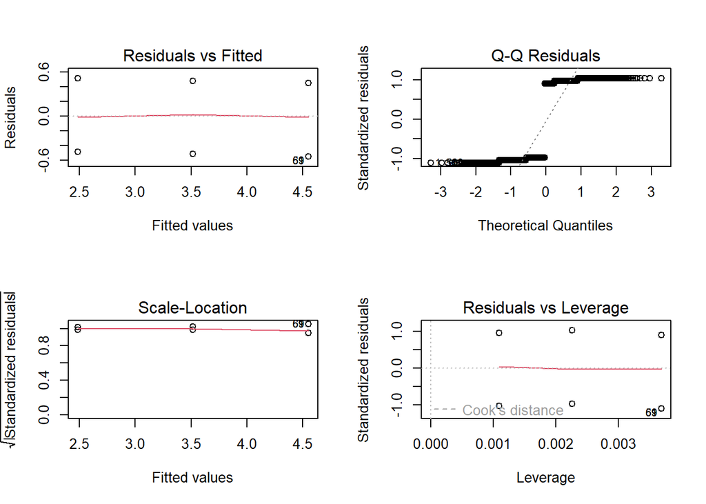

```r
#residual diagnostics
par(mfrow = c(2, 2))
plot(model)
```

If we look at the P value for the F statistic, we see that it is significant meaning that it is useful model with this particular regression when it comes to explained the variance of the data. And seeing how the p-value hardly dropped, it seems essentially most of all of the regression model was explained by the Experience level of the gym goers. And based off the positive coefficient, as experience level goes up, so does the frequency of attendance. the Diagnostic plots show that the residuals could be more normally distributed which we can explore in the plot below.

Lets plot this interaction below using ggplot:

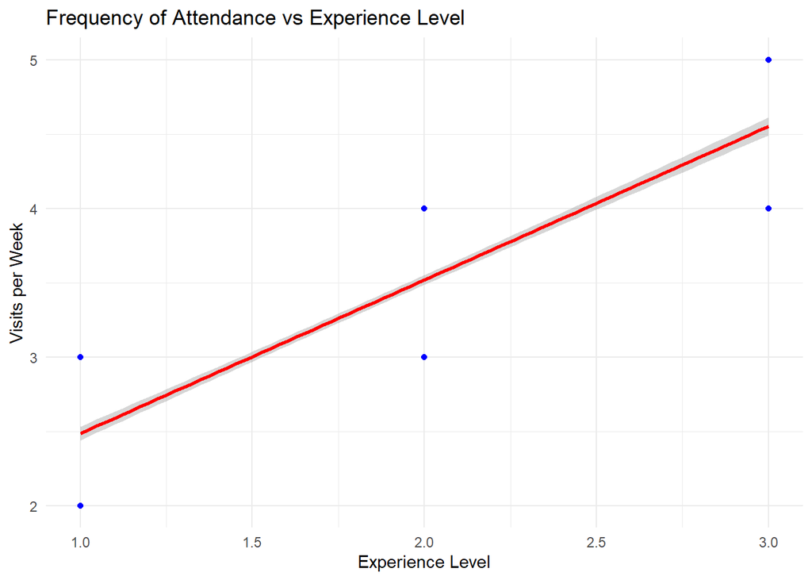

```r
ggplot(gym_data, aes(x = ExpLvl, y = Freq)) +
  geom_point(color = "blue") +  # Scatter plot points
  geom_smooth(method = "lm", color = "red", se = TRUE) +  # Regression line with confidence interval
  ggtitle("Frequency of Attendance vs Experience Level") +
  xlab("Experience Level") +
  ylab("Visits per Week") +
  theme_minimal()
```

This plot helps explain the QQ plot from above but also shows the linear relationship of the model.

Now let’s try adding some interaction terms that may help explain the regression model more:

```r
#single linear regression of different variables
model_interaction <- lm(Freq ~ ExpLvl +  ExpLvl*WorkoutType + ExpLvl*Gender, data = gym_data)
summary(model_interaction)
```

```
##
## Call:
## lm(formula = Freq ~ ExpLvl + ExpLvl * WorkoutType + ExpLvl *
##     Gender, data = gym_data)
##
## Residuals:
##     Min      1Q  Median      3Q     Max
## -0.5941 -0.5030  0.4059  0.4863  0.5992
##
## Coefficients:
##                            Estimate Std. Error t value Pr(>|t|)
## (Intercept)                 1.43444    0.09033  15.879   <2e-16 ***
## ExpLvl                      1.04374    0.04771  21.877   <2e-16 ***
## WorkoutTypeHIIT             0.12165    0.11968   1.016    0.310
## WorkoutTypeStrength         0.14649    0.11704   1.252    0.211
## WorkoutTypeYoga             0.06323    0.11934   0.530    0.596
## GenderMale                 -0.12436    0.08534  -1.457    0.145
## ExpLvl:WorkoutTypeHIIT     -0.05794    0.06163  -0.940    0.347
## ExpLvl:WorkoutTypeStrength -0.04481    0.06113  -0.733    0.464
## ExpLvl:WorkoutTypeYoga     -0.03841    0.06102  -0.629    0.529
## ExpLvl:GenderMale           0.04692    0.04361   1.076    0.282
## ---
## Signif. codes:  0 '***' 0.001 '**' 0.01 '*' 0.05 '.' 0.1 ' ' 1
##
## Residual standard error: 0.5 on 963 degrees of freedom
## Multiple R-squared:  0.7028, Adjusted R-squared:  0.7001
## F-statistic: 253.1 on 9 and 963 DF,  p-value: < 2.2e-16
```

And based off that it seems that only Experience level once again has any significance when it comes to this regression.

Let’s take a step back from Frequency as a predictor variable and start doing multivariate analysis with multiple response and predictor variables using the cbind:

```r
manova_model <- manova(cbind(Freq, Duration, CaloriesBurned) ~ ExpLvl + Gender + WorkoutType + WaterIntake, data = gym_data)

# View the summary of the MANOVA
summary(manova_model)
```

```
##              Df  Pillai approx F num Df den Df    Pr(>F)
## ExpLvl        1 0.79013  1209.75      3    964 < 2.2e-16 ***
## Gender        1 0.15102    57.16      3    964 < 2.2e-16 ***
## WorkoutType   3 0.01121     1.21      9   2898 0.2849763
## WaterIntake   1 0.02023     6.63      3    964 0.0001952 ***
## Residuals   966
## ---
## Signif. codes:  0 '***' 0.001 '**' 0.01 '*' 0.05 '.' 0.1 ' ' 1
```

So based off the output, it appears that ExpLvl, Gender, and WWater Intake have a significant predictive effect on the response variables.

So let’s do a Multivariate Analysis of these variables:

```r
#compute multivariate linear regression between the variables
mlm1 <- lm(cbind(Freq, Duration, CaloriesBurned) ~ ExpLvl + Gender + WorkoutType + WaterIntake, data = gym_data)
summary(mlm1)
```

```
## Response Freq :
##
## Call:
## lm(formula = Freq ~ ExpLvl + Gender + WorkoutType + WaterIntake,
##     data = gym_data)
##
## Residuals:
##     Min      1Q  Median      3Q     Max
## -0.6182 -0.5054  0.3818  0.4875  0.5641
##
## Coefficients:
##                      Estimate Std. Error t value Pr(>|t|)
## (Intercept)          1.457765   0.087105  16.736   <2e-16 ***
## ExpLvl               1.034593   0.023768  43.529   <2e-16 ***
## GenderMale          -0.035987   0.045010  -0.800    0.424
## WorkoutTypeHIIT      0.018426   0.045979   0.401    0.689
## WorkoutTypeStrength  0.066658   0.044188   1.509    0.132
## WorkoutTypeYoga     -0.007111   0.045138  -0.158    0.875
## WaterIntake         -0.003719   0.039319  -0.095    0.925
## ---
## Signif. codes:  0 '***' 0.001 '**' 0.01 '*' 0.05 '.' 0.1 ' ' 1
##
## Residual standard error: 0.4998 on 966 degrees of freedom
## Multiple R-squared:  0.7022, Adjusted R-squared:  0.7004
## F-statistic: 379.6 on 6 and 966 DF,  p-value: < 2.2e-16
##
##
## Response Duration :
##
## Call:
## lm(formula = Duration ~ ExpLvl + Gender + WorkoutType + WaterIntake,
##     data = gym_data)
##
## Residuals:
##     Min      1Q  Median      3Q     Max
## -0.4835 -0.1649 -0.0015  0.1464  0.5747
##
## Coefficients:
##                      Estimate Std. Error t value Pr(>|t|)
## (Intercept)          0.473604   0.038179  12.405  < 2e-16 ***
```

[output cut: 24 more lines]

```
## Coefficients:
##                     Estimate Std. Error t value Pr(>|t|)
## (Intercept)          315.659     33.346   9.466  < 2e-16 ***
## ExpLvl               244.798      9.099  26.904  < 2e-16 ***
## GenderMale            45.251     17.231   2.626  0.00877 **
## WorkoutTypeHIIT       16.681     17.602   0.948  0.34352
## WorkoutTypeStrength   13.138     16.916   0.777  0.43755
## WorkoutTypeYoga      -14.391     17.280  -0.833  0.40514
## WaterIntake           45.385     15.052   3.015  0.00264 **
## ---
## Signif. codes:  0 '***' 0.001 '**' 0.01 '*' 0.05 '.' 0.1 ' ' 1
##
## Residual standard error: 191.3 on 966 degrees of freedom
## Multiple R-squared:  0.5106, Adjusted R-squared:  0.5075
## F-statistic: 167.9 on 6 and 966 DF,  p-value: < 2.2e-16
```

Now to begin our final interpretation of the data of our multivariate analysis. For the response variable Frequency, it appears that as before, ExpLvl is the only predictor variable with significance to the model with Frequency increasing by 1.034593 in our model as ExpLvl increases by one unit.

For the response variable Duration it looks like ExpLvl, Gender, and Water Intake have a significant affect on our response variable, with Duration increasing by 0.336064 as ExpLvl increases by one unit, -0.069584 if the sex is male, and 0.074597 as water increases by one unit

For the response variable Calories it looks like ExpLvl, Gender, and Water Intake have a significant affect on our response variable, with Calories increasing by 244.798 as ExpLvl increases by one unit, 45.251 if the sex is male, and 45.385 as water increases by one unit.

So it looks like even if Males are in the gym for less time, they are actually burning more calories. And the amount of calories burned seems to be impacted by Experience level, which may be correlated to the higher metabolism of those with higher experience levels.

# Stepwise Regression

Let’s now try creating a better model using stepwise regression: Let’s also redefine the scope of the project to try and create a model that explains/predicts calories burned using significant predictor variables.

```r
# Create full model and empty model
full.model <- lm(CaloriesBurned ~ . , data = gym_data)
empty.model <- lm(CaloriesBurned ~ 1, data = gym_data)
# k = 2 for AIC selection
step.model <- step(empty.model,
scope = list(lower = empty.model,
upper = full.model),
direction = "both", k = 2)
```

```
## Start:  AIC=10914.47
## CaloriesBurned ~ 1
##
##               Df Sum of Sq      RSS     AIC
## + Duration     1  59587644 12664418  9222.1
## + ExpLvl       1  34812177 37439885 10276.8
## + FatPct       1  25804389 46447672 10486.6
## + Freq         1  23983997 48268064 10524.0
## + WaterIntake  1   9204877 63047184 10783.9
## + AvgBPM       1   8335577 63916485 10797.2
## + Age          1   1728668 70523393 10892.9
## + Gender       1   1639714 70612347 10894.1
## + Weight       1    658177 71593884 10907.6
## + Height       1    538710 71713351 10909.2
## + BMI          1    258038 71994024 10913.0
## <none>                     72252061 10914.5
## + RestBPM      1     19713 72232348 10916.2
## + MaxBPM       1       316 72251746 10916.5
## + WorkoutType  3    211670 72040391 10917.6
##
## Step:  AIC=9222.13
## CaloriesBurned ~ Duration
##
##               Df Sum of Sq      RSS     AIC
## + AvgBPM       1   7638999  5025418  8324.8
## + Gender       1   1890050 10774368  9066.9
## + Age          1   1348647 11315771  9114.6
## + Weight       1    840624 11823794  9157.3
## + WaterIntake  1    778627 11885791  9162.4
## + Height       1    660634 12003784  9172.0
## + FatPct       1    527523 12136895  9182.7
## + BMI          1    311481 12352937  9199.9
## + RestBPM      1     72339 12592079  9218.6
## <none>                     12664418  9222.1
## + Freq         1      9606 12654812  9223.4
## + MaxBPM       1      3579 12660839  9223.9
## + ExpLvl       1        26 12664392  9224.1
## + WorkoutType  3     20930 12643488  9226.5
## - Duration     1  59587644 72252061 10914.5
##
```

[output cut: 64 more lines]

```
## <none>                      1514773  7163.9
## + Weight       1      2972  1511800  7164.0
## + BMI          1      2954  1511819  7164.0
## + FatPct       1      2328  1512445  7164.4
## + Freq         1      1143  1513630  7165.2
## + WorkoutType  3      7109  1507663  7165.4
## + ExpLvl       1       256  1514517  7165.8
## + Height       1       211  1514561  7165.8
## + MaxBPM       1       148  1514625  7165.8
## + WaterIntake  1         0  1514772  7165.9
## - RestBPM      1      7670  1522442  7166.8
## - Age          1   1687171  3201943  7890.2
## - Gender       1   1905598  3420371  7954.4
## - AvgBPM       1   7757840  9272613  8924.8
## - Duration     1  58717021 60231794 10745.4
```

Using stepwise regression, we find that the best model of Calories Burned are Duration, AvgBPM, Gender, Age, RestBPM.

Let’s test that with an Muiltiple Linear Regression

```r
mlr_model <- lm(CaloriesBurned ~ Duration + AvgBPM + Gender + Age + RestBPM, data = gym_data)
summary(mlr_model)
```

```
##
## Call:
## lm(formula = CaloriesBurned ~ Duration + AvgBPM + Gender + Age +
##     RestBPM, data = gym_data)
##
## Residuals:
##      Min       1Q   Median       3Q      Max
## -127.488  -25.236   -2.618   22.999  176.554
##
## Coefficients:
##               Estimate Std. Error t value Pr(>|t|)
## (Intercept) -830.99325   17.32206 -47.973   <2e-16 ***
## Duration     716.89529    3.70283 193.607   <2e-16 ***
## AvgBPM         6.24407    0.08873  70.374   <2e-16 ***
## GenderMale    88.67187    2.54232  34.878   <2e-16 ***
## Age           -3.42446    0.10435 -32.819   <2e-16 ***
## RestBPM        0.38415    0.17361   2.213   0.0272 *
## ---
## Signif. codes:  0 '***' 0.001 '**' 0.01 '*' 0.05 '.' 0.1 ' ' 1
##
## Residual standard error: 39.58 on 967 degrees of freedom
## Multiple R-squared:  0.979,  Adjusted R-squared:  0.9789
## F-statistic:  9031 on 5 and 967 DF,  p-value: < 2.2e-16
```